# University of Tehran

## Classification

## Q21

**Pruning** is a technique used in decision trees to reduce their complexity by removing certain branches or nodes. Here's how it works:

1. **What is Pruning?**
   - Decision trees are prone to overfitting, especially when they grow too deep and capture noise in the training data. Pruning helps prevent overfitting by simplifying the tree.
   - Pruning involves removing parts of the tree that do not contribute significantly to improving its performance on unseen data.
2. **Types of Pruning:**
   - **Pre-Pruning (Early Stopping):** In pre-pruning, we stop growing the tree before it becomes too complex. We set conditions (such as a maximum depth or minimum number of samples per leaf) to limit growth.
   - **Post-Pruning (Cost-Complexity Pruning):** Post-pruning involves growing the full tree and then selectively removing branches. We assign a cost to each branch and iteratively prune the branches with the highest cost until we achieve an optimal balance between accuracy and simplicity.
3. **Advantages of Pruning:**
   - **Reduced Overfitting:** Pruning prevents overfitting by simplifying the tree. A smaller tree is less likely to fit noise in the training data.
   - **Improved Generalization:** Pruned trees generalize better to unseen data because they focus on essential features rather than memorizing the training data.
   - **Interpretability:** Smaller trees are easier to interpret and explain to stakeholders.
4. **Disadvantages of Pruning:**
   - **Loss of Information:** Pruning may remove relevant features or patterns from the tree, leading to a decrease in accuracy.
   - **Tuning Complexity:** Choosing the right pruning parameters (e.g., cost complexity factor) can be challenging.
   - **Risk of Underfitting:** Over-pruning can lead to underfitting if too many branches are removed.

In summary, pruning strikes a balance between model complexity and accuracy, making decision trees more robust and interpretable. It's an essential step in building effective decision tree models¹²³.

Source: Conversation with Bing, 5/16/2024 (1) درخت تصمیم (Decision Tree) – تعریف، مزایا و کاربردها. https://quera.org/blog/what-is-a-decision-tree/. (2) الگوریتم درخت تصمیم و انواع درخت های تصمیم گیری | آکادمی داده. https://www.dataacademy.ir/%D8%A7%D9%84%DA%AF%D9%88%D8%B1%DB%8C%D8%AA%D9%85-%D8%AF%D8%B1%D8%AE%D8%AA-%D8%AA%D8%B5%D9%85%DB%8C%D9%85-%D9%88-%D8%A7%D9%86%D9%88%D8%A7%D8%B9-%D8%AF%D8%B1%D8%AE%D8%AA-%D9%87%D8%A7%DB%8C-%D8%AA%D8%B5%D9%85%DB%8C%D9%85-%DA%AF%DB%8C%D8%B1%DB%8C. (3) درخت تصمیم گیری چیست و چه کاربردهایی دارد؟ - انگیزه. https://angize.com/26320/%d8%af%d8%b1%d8%ae%d8%aa-%d8%aa%d8%b5%d9%85%db%8c%d9%85-%da%af%db%8c%d8%b1%db%8c-%da%86%db%8c%d8%b3%d8%aa-%da%86%d9%87-%da%a9%d8%a7%d8%b1%d8%a8%d8%b1%d8%af%db%8c-%d8%af%d8%a7%d8%b1%d8%af/. (4) درخت تصمیم (Decision Tree) چیست؟ مراحل ترسیم + مزایا و معایب. https://sokanacademy.com/blog/decision-tree-%D8%AF%D8%B1%D8%AE%D8%AA-%D8%AA%D8%B5%D9%85%DB%8C%D9%85-%DA%86%DB%8C%D8%B3%D8%AA. (5) درخت تصمیم در یادگیری ماشین — به زبان ساده + نمونه کد. https://blog.faradars.org/%D8%AF%D8%B1%D8%AE%D8%AA-%D8%AA%D8%B5%D9%85%DB%8C%D9%85-%D8%AF%D8%B1-%DB%8C%D8%A7%D8%AF%DA%AF%DB%8C%D8%B1%DB%8C-%D9%85%D8%A7%D8%B4%DB%8C%D9%86/. (6) en.wikipedia.org. https://en.wikipedia.org/wiki/Decision_tree.

## Q22

**Decision trees** have several advantages over other models in specific scenarios. Let's explore those:

1. **Interpretability:**
   - Decision trees are easy to interpret and explain. The structure resembles human decision-making, making it intuitive for data experts.
   - When transparency and understanding of the model are crucial, decision trees shine.
2. **Handling Nonlinear Relationships:**
   - Decision trees can capture nonlinear relationships between features and the target variable.
   - Unlike linear models, they don't assume a linear relationship, which is beneficial when the underlying data is complex.
3. **Feature Importance:**
   - Decision trees provide feature importance scores. You can identify which features contribute most to the model's predictions.
   - This information helps in feature selection and understanding the data.
4. **Mixed Data Types:**
   - Decision trees handle both categorical and numerical features without requiring extensive preprocessing.
   - Other models may struggle with mixed data types.
5. **Robustness to Outliers:**
   - Decision trees are less affected by outliers compared to linear models.
   - Outliers don't significantly impact the tree's structure.
6. **Non-Linear Decision Boundaries:**
   - Decision trees can create complex decision boundaries, adapting well to irregularly shaped data clusters.
   - In contrast, linear models assume linear decision boundaries.
7. **Ensemble Methods (Random Forests, Gradient Boosting):**
   - Decision trees serve as building blocks for powerful ensemble methods like Random Forests and Gradient Boosting.
   - These ensembles combine multiple decision trees to improve overall performance.

Source: Conversation with Bing, 5/16/2024 (1) درخت تصمیم گیری چیست و چه کاربردهایی دارد؟ - انگیزه. https://bing.com/search?q=%d8%a7%d8%b3%d8%aa%d9%81%d8%a7%d8%af%d9%87+%d8%a7%d8%b2+%d8%af%d8%b1%d8%ae%d8%aa%d9%87%d8%a7%db%8c+%d8%aa%d8%b5%d9%85%db%8c%d9%85+%da%af%db%8c%d8%b1%db%8c+%da%86%d9%87+%d8%b2%d9%85%d8%a7%d9%86%db%8c+%d9%85%db%8c+%d8%aa%d9%88%d8%a7%d9%86%d8%af+%d9%86%d8%b3%d8%a8%d8%aa+%d8%a8%d9%87+%d8%b3%d8%a7%db%8c%d8%b1+%d9%85%d8%af%d9%84+%d9%87%d8%a7+%d8%af%d8%a7%d8%b1%d8%a7%db%8c+%d9%85%d8%b2%db%8c%d8%aa+%d8%a8%d8%a7%d8%b4%d8%af%d8%9f. (2) درخت تصمیم گیری چیست و چه کاربردهایی دارد؟ - انگیزه. https://angize.com/26320/%d8%af%d8%b1%d8%ae%d8%aa-%d8%aa%d8%b5%d9%85%db%8c%d9%85-%da%af%db%8c%d8%b1%db%8c-%da%86%db%8c%d8%b3%d8%aa-%da%86%d9%87-%da%a9%d8%a7%d8%b1%d8%a8%d8%b1%d8%af%db%8c-%d8%af%d8%a7%d8%b1%d8%af/. (3) 30 پرسش و پاسخ درباره‌ی مدل‌های درختی – فرادرس - مجله‌. https://blog.faradars.org/%D9%86%D9%85%D9%88%D9%86%D9%87-%D8%B3%D9%88%D8%A7%D9%84-%D9%85%D8%AF%D9%84%E2%80%8C%D9%87%D8%A7%DB%8C-%D8%AF%D8%B1%D8%AE%D8%AA%DB%8C/. (4) درخت تصمیم (Decision Tree) – تعریف، مزایا و کاربردها. https://quera.org/blog/what-is-a-decision-tree/. (5) درخت تصمیم در یادگیری ماشین — به زبان ساده + نمونه کد. https://blog.faradars.org/%D8%AF%D8%B1%D8%AE%D8%AA-%D8%AA%D8%B5%D9%85%DB%8C%D9%85-%D8%AF%D8%B1-%DB%8C%D8%A7%D8%AF%DA%AF%DB%8C%D8%B1%DB%8C-%D9%85%D8%A7%D8%B4%DB%8C%D9%86/.

## Q23

1. **K-Nearest Neighbors (KNN):**
   - **Algorithm:** KNN is a **non-parametric** algorithm.
   - **Working:** It assigns a data point to the class most common among its **k nearest neighbors** in the feature space.
   - **Training Process:** KNN does **minimal training** during the training phase. It essentially memorizes the training data.
   - **Assumptions:** KNN makes **no assumptions** about the underlying data distribution and is **non-linear**.
   - **Model Type:** KNN is a **non-parametric model**, meaning it doesn't assume a specific functional form for the decision boundary.
   - **Handling Outliers:** KNN can be sensitive to outliers, which may affect the estimated coefficients.
2. **Logistic Regression:**
   - **Algorithm:** Logistic Regression is a **parametric** algorithm.
   - **Working:** It predicts the **likelihood** of an instance belonging to a particular category.
   - **Training Process:** Logistic Regression estimates parameters by minimizing the **logistic loss function** using techniques like **gradient descent**.
   - **Assumptions:** It assumes a **linear relationship** between features and the log odds of variables.
   - **Model Type:** Logistic Regression is a **parametric model**, meaning it assumes a specific functional form (sigmoid) for the decision boundary.
   - **Handling Outliers:** Logistic Regression can be affected by outliers since it estimates coefficients based on the data.
3. **Neural Networks (NNs):**
   - **Algorithm:** Neural networks are a class of **parametric** models.
   - **Working:** NNs consist of interconnected layers of artificial neurons (nodes) that learn from data.
   - **Training Process:** NNs learn through **backpropagation** by adjusting weights during training.
   - **Assumptions:** They can model both **linear and non-linear** relationships.
   - **Model Type:** NNs are **parametric models**, but their flexibility allows them to capture complex patterns.
   - **Handling Outliers:** NNs can handle outliers, but their performance depends on architecture and regularization.

In summary:

- **KNN** is simple, non-parametric, and suitable for diverse, non-linear data.
- **Logistic Regression** is efficient, interpretable, and works well when the relationship is linear or logistic.
- **Neural Networks** are powerful, flexible, and can handle complex relationships but require more data and computational resources⁵⁶⁷⁸.

Source: Conversation with Bing, 5/16/2024 (1) Logistic Regression vs K Nearest Neighbors in Machine Learning. https://www.geeksforgeeks.org/logistic-regression-vs-k-nearest-neighbors-in-machine-learning/. (2) Comparative Study on Classic Machine learning Algorithms. https://towardsdatascience.com/comparative-study-on-classic-machine-learning-algorithms-24f9ff6ab222. (3) Classification Algorithms: KNN, Naive Bayes, and Logistic Regression. https://medium.com/@brandon93.w/classification-algorithms-knn-naive-bayes-and-logistic-regression-515bdb085047. (4) KNN vs Logistic Regression: Differences, Examples - Data Analytics. https://vitalflux.com/knn-vs-logistic-regression-differences-examples/. (5) پیاده سازی الگوریتم KNN با پایتون — راهنمای کاربردی. https://blog.faradars.org/%D9%BE%DB%8C%D8%A7%D8%AF%D9%87-%D8%B3%D8%A7%D8%B2%DB%8C-%D8%A7%D9%84%DA%AF%D9%88%D8%B1%DB%8C%D8%AA%D9%85-knn-%D8%A8%D8%A7-%D9%BE%D8%A7%DB%8C%D8%AA%D9%88%D9%86/. (6) الگوریتم K نزدیک ترین همسایه (KNN) | چیستیو | علوم داده و نرم افزار. https://chistio.ir/%d8%a7%d9%84%da%af%d9%88%d8%b1%db%8c%d8%aa%d9%85-k-%d9%86%d8%b2%d8%af%db%8c%da%a9-%d8%aa%d8%b1%db%8c%d9%86-%d9%87%d9%85%d8%b3%d8%a7%db%8c%d9%87-knn/. (7) تفاوت طبقه بندی و خوشه بندی در یادگیری ماشین چیست؟ – ۳ فرق کلیدی. https://blog.faradars.org/%D8%AA%D9%81%D8%A7%D9%88%D8%AA-%D8%B7%D8%A8%D9%82%D9%87-%D8%A8%D9%86%D8%AF%DB%8C-%D9%88-%D8%AE%D9%88%D8%B4%D9%87-%D8%A8%D9%86%D8%AF%DB%8C/. (8) الگوریتم Knn یا الگوریتم K نزدیکترین همسایه. https://raahbord.com/knn-algorithm/.

## Q24

1. **What is the K-Nearest Neighbors Algorithm?**
   - KNN is a **supervised machine learning** method used for both classification and regression tasks.
   - It finds application in pattern recognition, data mining, and intrusion detection.
   - KNN is non-parametric, meaning it doesn't assume any specific data distribution (unlike algorithms like Gaussian Mixture Models).
   - Given training data with labeled coordinates, KNN assigns new data points to groups based on their nearest neighbors.
2. **Intuition Behind KNN:**
   - Imagine plotting data points on a graph. Clusters or groups may emerge.
   - For an unclassified point, we look at its nearest neighbors (based on a distance metric like Euclidean distance).
   - The majority class of these neighbors determines the class of the unclassified point.
3. **Advantages of KNN:**
   - **Easy Implementation:** KNN is straightforward to implement due to its simplicity.
   - **Adaptability:** It adjusts itself when new examples are added to the dataset.
   - **Handling Numerical and Categorical Data:** KNN works well with both types of data.
   - **Robustness to Noisy Data:** It is robust even when data contains noise or outliers.
4. **Disadvantages of KNN:**
   - **Computational Cost:** Determining the optimal value of K can be expensive for large datasets.
   - **Memory Usage:** KNN stores all data in memory, which can be memory-intensive.
   - **Slow Prediction Phase:** Predicting for new data points can be slow for large datasets.

In summary, KNN is versatile, adapts easily, and handles various data types. However, it has computational and memory limitations¹²³.

Source: Conversation with Bing, 5/16/2024 (1) K-Nearest Neighbor(KNN) Algorithm - GeeksforGeeks. https://www.geeksforgeeks.org/k-nearest-neighbours/. (2) Pros and cons of the K-Nearest Neighbors (KNN) algorithm - RoboticsBiz. https://roboticsbiz.com/pros-and-cons-of-the-k-nearest-neighbors-knn-algorithm/. (3) Nearest Neighbors Algorithm | Advantages and Disadvantages - EDUCBA. https://www.educba.com/nearest-neighbors-algorithm/. (4) What is the k-nearest neighbors algorithm? | IBM. https://www.ibm.com/topics/knn.

## Q25

1. **Euclidean Distance**:
   - **Definition:** Euclidean distance is the most commonly employed metric in KNN.
   - **Formula:** Given two points, $$\mathbf{p} = (p_1, p_2, \ldots, p_n)$$ and $$\mathbf{q} = (q_1, q_2, \ldots, q_n)$$, the Euclidean distance between them is calculated as: $$d(\mathbf{p}, \mathbf{q}) = \sqrt{\sum_{i=1}^{n} (p_i - q_i)^2}$$
   - **Explanation:** It measures the straight-line distance between two points in Euclidean space.
   - **Use Case:** Suitable for continuous features and when the data distribution is approximately Gaussian.
2. **Manhattan Distance (Taxicab Distance)**:
   - **Definition:** Manhattan distance is calculated by summing the absolute differences between corresponding coordinates.
   - **Formula:** For points $$\mathbf{p}$$ and $$\mathbf{q}$$: $$d(\mathbf{p}, \mathbf{q}) = \sum_{i=1}^{n} |p_i - q_i|$$
   - **Explanation:** It represents the distance traveled along grid lines (like a taxi moving in a city).
   - **Use Case:** Preferred over Euclidean distance for high-dimensional data.
3. **Minkowski Distance**:
   - **Definition:** Minkowski distance is a generalized metric that includes both Euclidean and Manhattan distances.
   - **Formula:** For points $$\mathbf{p}$$ and $$\mathbf{q}$$: $$d(\mathbf{p}, \mathbf{q}) = \left(\sum_{i=1}^{n} |p_i - q_i|^p\right)^{\frac{1}{p}}$$
   - **Special Cases:**
     - When $$p = 1$$, it becomes Manhattan distance.
     - When $$p = 2$$, it becomes Euclidean distance.
   - **Use Case:** Depends on the specific problem and data characteristics.
4. **Cosine Similarity**:
   - **Definition:** Cosine similarity measures the cosine of the angle between two vectors.
   - **Formula:** For vectors $$\mathbf{p}$$ and $$\mathbf{q}$$: $$\text{cosine similarity} = \frac{\mathbf{p} \cdot \mathbf{q}}{\|\mathbf{p}\| \|\mathbf{q}\|}$$
   - **Explanation:** It captures the direction of vectors rather than their magnitude.
   - **Use Case:** Useful for text data, collaborative filtering, and recommendation systems.

Source: Conversation with Bing, 5/16/2024 (1) Most Popular Distance Metrics Used in KNN and When to Use Them. https://www.kdnuggets.com/2020/11/most-popular-distance-metrics-knn.html. (2) What is k-Nearest Neighbor (kNN)? | A Comprehensive k-Nearest ... - Elastic. https://www.elastic.co/what-is/knn. (3) K-Nearest Neighbor(KNN) Algorithm - GeeksforGeeks. https://www.geeksforgeeks.org/k-nearest-neighbours/. (4) K-Nearest Neighbors Algorithm: A Clear Explanation with Examples and Math. https://www.dataharnessing.com/data-science-tutorials/knn-algorithm-explained-examples-math-classification-regression/. (5) How KNN Uses Distance Measures? - Analytics Vidhya. https://www.analyticsvidhya.com/blog/2021/08/how-knn-uses-distance-measures/.

```python
top_threshold = linearData['MEDV'].quantile(0.8)
bottom_threshold = linearData['MEDV'].quantile(0.2)
linearData['category'] = 0
linearData.loc[linearData['MEDV'] >= top_threshold, 'category'] = 1
linearData.loc[linearData['MEDV'] <= bottom_threshold, 'category'] = 2
categrizedData = linearData.drop(columns=['MEDV'])
```

```python
X_train, X_test, y_train, y_test = \
    train_test_split(categrizedData.drop(columns=['category']), categrizedData['category'], test_size=0.2)
```

```python
display(X_train)
display(y_train)
```

|  | CRIM | ZN | INDUS | NOX | RM | AGE | RAD | TAX | PTRATIO | B | LSTAT |
| --- | --- | --- | --- | --- | --- | --- | --- | --- | --- | --- | --- |
| 447 | 3.611285 | -0.577404 | 1.241856 | -0.219511 | -0.346733 | 1.144658 | -0.265875 | 1.809959 | -0.256175 | 0.438353 | 0.809085 |
| 301 | -0.514773 | 0.899193 | -0.434924 | -0.406096 | -0.334266 | -0.554700 | -0.349478 | -0.057165 | -0.303033 | 0.497333 | -0.336331 |
| 401 | -0.529530 | 0.208667 | -1.285180 | 3.185818 | 3.100772 | -1.728705 | 2.891384 | -1.768049 | 4.049034 | -2.565325 | -0.715935 |
| 426 | -0.529530 | 0.208667 | -1.285180 | 2.878287 | 1.618789 | -1.715899 | 2.891384 | -1.768049 | -0.205317 | -2.603095 | -0.220799 |
| 390 | 2.375197 | -0.577404 | 1.241856 | -0.243822 | -0.366517 | 1.156753 | -0.265875 | 1.809959 | -0.256175 | 0.486565 | 0.919665 |
| ... | ... | ... | ... | ... | ... | ... | ... | ... | ... | ... | ... |
| 12 | -0.490403 | -0.034537 | -0.186408 | -0.350789 | -0.360045 | -0.597033 | -0.359314 | -0.156893 | -0.313319 | 0.454505 | 0.688602 |
| 75 | -0.489844 | -0.577404 | 0.506083 | -0.403665 | -0.345445 | -0.415607 | -0.359314 | 0.325125 | -0.273318 | 0.395198 | -0.428756 |
| 354 | -0.511585 | 2.896943 | -1.018515 | -0.418252 | -0.368356 | -1.114097 | -0.364232 | -0.029463 | -0.235603 | 0.391691 | -0.575647 |
| 174 | -0.494287 | -0.577404 | -0.719739 | -0.359298 | -0.361148 | 0.301026 | -0.359314 | -0.239999 | -0.297319 | 0.476776 | -0.313224 |
| 197 | -0.510062 | 2.896943 | -1.072965 | -0.423721 | -0.315254 | -0.669603 | -0.374068 | -0.057165 | -0.343034 | 0.159277 | -0.483221 |

404 rows × 11 columns

```
447    2
301    0
401    2
426    2
390    2
      ..
12     0
75     0
354    0
174    0
197    1
Name: category, Length: 404, dtype: int64
```

```python
display(X_test)
```

|  | CRIM | ZN | INDUS | NOX | RM | AGE | RAD | TAX | PTRATIO | B | LSTAT |
| --- | --- | --- | --- | --- | --- | --- | --- | --- | --- | --- | --- |
| 294 | -0.495322 | -0.577404 | 0.658264 | -0.403665 | -0.355632 | -0.497248 | -0.364232 | -0.278782 | -0.304176 | 0.506715 | -0.187790 |
| 69 | -0.476059 | -0.034537 | -0.437716 | -0.420683 | -0.360192 | -0.778459 | -0.364232 | 0.031482 | -0.271033 | 0.506715 | -0.453513 |
| 125 | -0.459012 | -0.577404 | 2.295951 | -0.316146 | -0.356478 | 0.896709 | -0.374068 | -0.838365 | -0.268747 | 0.409801 | 0.540061 |
| 492 | -0.483085 | -0.577404 | 2.587747 | -0.299129 | -0.356588 | 0.748544 | -0.364232 | 2.059279 | -0.257318 | 0.506715 | 0.299094 |
| 187 | -0.496674 | 1.376916 | -0.804904 | -0.403665 | -0.327206 | -0.533534 | -0.359314 | 0.325125 | -0.313319 | 0.481997 | -0.801759 |
| ... | ... | ... | ... | ... | ... | ... | ... | ... | ... | ... | ... |
| 164 | 0.406021 | -0.577404 | 1.448486 | -0.301560 | -0.361332 | 0.999517 | -0.359314 | 0.352827 | -0.319033 | 0.492112 | 0.016867 |
| 18 | -0.194626 | -0.577404 | -0.148712 | -0.342280 | -0.375968 | -0.669603 | -0.364232 | -0.179054 | -0.247032 | -0.373586 | 0.025119 |
| 346 | -0.503821 | -0.577404 | -0.672269 | -0.400626 | -0.359714 | -0.194872 | -0.369150 | 0.070265 | -0.272175 | 0.243301 | 0.186863 |
| 57 | -0.523555 | 3.765529 | -1.100888 | -0.419467 | -0.325955 | -0.551676 | -0.359314 | -0.461616 | -0.314462 | 0.474084 | -1.252333 |
| 123 | -0.466789 | -0.577404 | 2.295951 | -0.316146 | -0.361258 | 1.156753 | -0.374068 | -0.838365 | -0.268747 | 0.289801 | 2.289543 |

102 rows × 11 columns

```python
from abc import ABC, abstractmethod
from sklearn import metrics
from sklearn.model_selection import GridSearchCV
from sklearn.metrics import classification_report

class ClassifierModel(ABC):
    def __init__(self, X_train, y_train, y_test, params):
        self.classifier = self.create_classifier(params)
        self.search_params = self.set_search_params()
        self.classifier.fit(X_train, y_train)
        self.train_accuracy = self.calc_accuracy(X_train, y_train)
        self.y_test = y_test

    @abstractmethod
    def create_classifier(self, params):
        pass

    @abstractmethod
    def set_search_params(self):
        pass

    def predict(self, data):
        return self.classifier.predict(data)

    def get_train_accuracy(self):
        return self.train_accuracy

    def calc_accuracy(self, X_test, y_test):
        self.preds = self.predict(X_test)
        accuracy = metrics.accuracy_score(y_test, self.preds)
        return accuracy

    def grid_search(self, X_train, y_train, X_test, y_test):
        grid = GridSearchCV(self.classifier, self.search_params, scoring='accuracy', n_jobs = 2)
        grid.fit(X_train, y_train)
        test_score = grid.score(X_test, y_test)
        return grid, test_score

    def draw_confusion_matrix(self, X_test, y_test):
        preds = self.classifier.predict(X_test)
        confusion_matrix = metrics.confusion_matrix(y_test, preds)
        fig, ax = plt.subplots(figsize=(8, 6))
        matrix_plot = metrics.ConfusionMatrixDisplay(confusion_matrix)
        matrix_plot.plot(cmap='Blues', ax = ax)
        plt.title('Confusion Matrix')
        plt.show()

    def get_classif_report(self):
        return(classification_report(y_test, self.preds))
```

```python
def runModel(Model, X_train, y_train, X_test, y_test, params):
    model = Model(X_train, y_train, y_test, params)
    print(f"model's train accuracy: {model.get_train_accuracy(): 0.3f}")
    print(f"model's test accuracy: {model.calc_accuracy(X_test, y_test): 0.3f}")
    grid, test_score = model.grid_search(X_train, y_train, X_test, y_test)
    print(f"Best hyperparameters: {grid.best_params_}")
    print(f"Best model's train accuracy score: {grid.best_score_:0.3f}")
    print(f"Best model's test score: {test_score:0.3f}")
    print(f"Classification report : \n{model.get_classif_report()}")
    model.draw_confusion_matrix(X_test, y_test)
    return(model.classifier)
```

### Decision tree

A decision tree is a supervised learning algorithm that predicts a target variable by recursively partitioning the feature space into subsets based on the values of the input features. It creates a tree structure where each internal node represents a test on a feature, each branch represents an outcome of the test, and each leaf node represents a class label or a regression value. The hyperparameters that I change are:

- `criterion` refers to the function used to measure the quality of a split.
- `Max_depth` is the maximum depth of the decision tree.
- `Min_samples_split` is the minimum number of samples required to split an internal node.
- `min_samples_leaf` is the minimum number of samples required to be at a leaf node.

```python
from sklearn.tree import DecisionTreeClassifier

class DecisionTreeModel(ClassifierModel):
    def create_classifier(self, params):
        return DecisionTreeClassifier(criterion=params["criterion"], max_depth=params["max_depth"],
                                      min_samples_split=params["min_samples_split"], min_samples_leaf=params["min_samples_leaf"])

    def set_search_params(self):
        return {
            'criterion': ["gini", "entropy"],
            'max_depth': range(5, 10),
            'min_samples_split': range(3, 10),
            'min_samples_leaf': range(1, 6),
        }
```

```
model's train accuracy:  0.899
model's test accuracy:  0.853
Best hyperparameters: {'criterion': 'entropy', 'max_depth': 9, 'min_samples_leaf': 1, 'min_samples_split': 4}
Best model's train accuracy score: 0.824
Best model's test score: 0.863
Classification report :
              precision    recall  f1-score   support

           0       0.84      0.95      0.89        65
           1       0.87      0.72      0.79        18
           2       0.92      0.63      0.75        19

    accuracy                           0.85       102
   macro avg       0.88      0.77      0.81       102
weighted avg       0.86      0.85      0.85       102
```

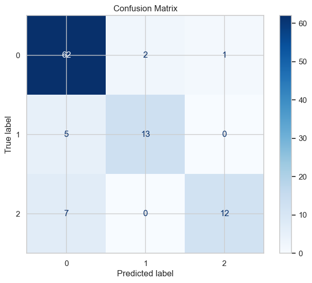

```python
params = {
        'criterion': "entropy",
        'max_depth': 8,
        'min_samples_split': 5,
        'min_samples_leaf': 8,
}
classifier = runModel(DecisionTreeModel, X_train, y_train, X_test, y_test, params)
```

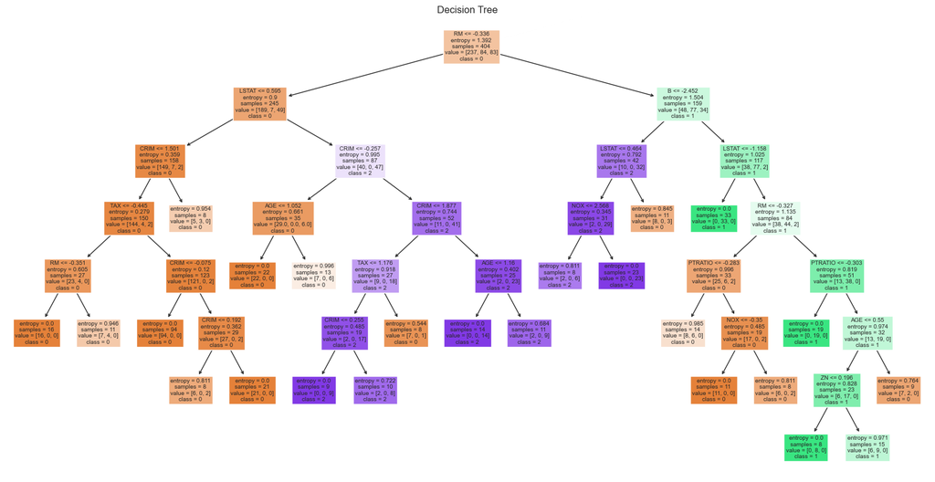

```python
from sklearn.tree import plot_tree
plt.figure(figsize=(20, 10))
plot_tree(classifier, filled=True, feature_names=X_train.columns, class_names=[str(i) for i in set(y_train)])
plt.title("Decision Tree")
plt.show()
```

### KNN

```python
X_train2 = std_scaler.fit_transform(X_train)
X_test2 = std_scaler.fit_transform(X_test)
```

```python
from sklearn.neighbors import KNeighborsClassifier


class KNNModel(ClassifierModel):
    def create_classifier(self, params):
        return KNeighborsClassifier(n_neighbors=params["n_neighbors"])

    def set_search_params(self):
        return {
                'n_neighbors' : range(1, 90)
        }
```

```
model's train accuracy:  0.780
model's test accuracy:  0.794
Best hyperparameters: {'n_neighbors': 1}
Best model's train accuracy score: 0.799
Best model's test score: 0.814
Classification report :
              precision    recall  f1-score   support

           0       0.79      0.92      0.85        65
           1       1.00      0.44      0.62        18
           2       0.72      0.68      0.70        19

    accuracy                           0.79       102
   macro avg       0.84      0.68      0.72       102
weighted avg       0.81      0.79      0.78       102
```

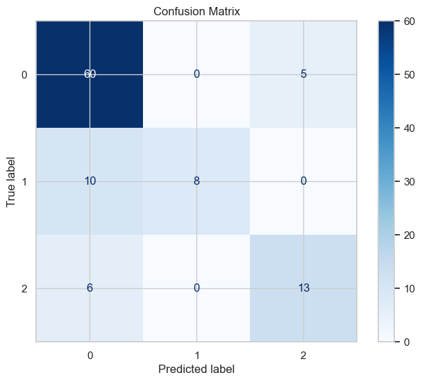

```python
params = {
        'n_neighbors' : 18
}
knnClassifier = runModel(KNNModel, X_train2, y_train, X_test2, y_test, params)
```

## Ensemble Learning

## Q30

1. **What Are Ensemble Methods?**
   - Ensemble methods combine predictions from multiple models to create a more robust and accurate final prediction.
   - These methods leverage the collective intelligence of diverse models, aiming to mitigate errors or biases inherent in individual models.
2. **Advantages of Ensemble Methods:**
   - **Improved Accuracy:** Ensembles often outperform individual models by combining their strengths.
   - **Robustness:** Ensembles are less sensitive to noise and outliers because they aggregate predictions from multiple sources.
   - **Generalization:** They generalize well to unseen data, reducing overfitting.
   - **Stability:** Ensembles are more stable due to their reliance on multiple models.
3. **Why Are Ensemble Methods Important Today?**
   - **Success in Competitions:** Ensembles have achieved remarkable success in machine learning competitions (e.g., Kaggle).
   - **Diverse Perspectives:** Combining different models provides diverse perspectives, leading to better overall performance.
   - **Bias-Variance Tradeoff:** Ensembles strike a balance between bias and variance, enhancing model robustness.
   - **Complexity Handling:** They handle complex relationships and non-linearities effectively.

Source: Conversation with Bing, 5/16/2024 (1) Why Use Ensemble Learning? - MachineLearningMastery.com. https://machinelearningmastery.com/why-use-ensemble-learning/. (2) Ensemble Learning : Ensemble Techniques - Analytics Vidhya. https://www.analyticsvidhya.com/blog/2018/06/comprehensive-guide-for-ensemble-models/. (3) Ensemble Methods in Machine Learning: What are They and Why Use Them .... https://towardsdatascience.com/ensemble-methods-in-machine-learning-what-are-they-and-why-use-them-68ec3f9fef5f. (4) Ensemble Classifier | Data Mining - GeeksforGeeks. https://www.geeksforgeeks.org/ensemble-classifier-data-mining/.

## Q31

1. **Bagging (Bootstrap Aggregating):**
   - **Definition:** Bagging is an ensemble meta-algorithm designed to improve the stability and accuracy of machine learning models used in statistical classification and regression.
   - **Objective:** It aims to reduce variance and avoid overfitting.
   - **Application:** Bagging is commonly applied to decision tree methods.
   - **Description:**
     - Bagging involves training multiple instances of the same base learning algorithm (usually decision trees) on different subsets of the training data.
     - Each subset is created by randomly sampling with replacement from the original dataset (a process called **bootstrap**).
     - The base models (learners) are trained independently in parallel.
     - The final prediction is determined by averaging the predictions from all the models.
   - **Advantages:**
     - Improved stability due to averaging.
     - Robustness to noise and outliers.
     - Effective for high-variance models.
   - **Example:** Random Forest, which uses bagging with decision trees.
2. **Boosting:**
   - **Definition:** Boosting is another ensemble technique that builds a strong classifier by sequentially combining weak learners.
   - **Objective:** It focuses on minimizing bias by correcting the mistakes of previous models.
   - **Workflow:**
     - A base model (weak learner) is built from the training data.
     - Subsequent models are built to correct the errors made by the previous ones.
     - Each new model adapts to the mistakes of its predecessor.
     - The final prediction is a weighted combination of all models.
   - **Advantages:**
     - Effective at reducing bias.
     - Sequential learning adapts to complex patterns.
     - Handles hard instances by emphasizing them.
   - **Example:** Gradient Boosting, AdaBoost.
3. **Differences:**
   - **Training Approach:**
     - **Bagging:** Independent parallel training of base models.
     - **Boosting:** Sequential adaptive learning.
   - **Focus:**
     - **Bagging:** Reducing variance.
     - **Boosting:** Minimizing bias.
   - **Handling Errors:**
     - **Bagging:** Averages predictions.
     - **Boosting:** Corrects errors iteratively.
   - **Robustness:**
     - **Bagging:** Effective on noisy data.
     - **Boosting:** Robust to outliers.

Source: Conversation with Bing, 5/16/2024 (1) Bagging vs Boosting in Machine Learning - GeeksforGeeks. https://www.geeksforgeeks.org/bagging-vs-boosting-in-machine-learning/. (2) Understanding the Difference between Bagging and Boosting. https://biztalktechie.com/bagging-vs-boosting/. (3) Bagging vs Boosting: Ensemble Techniques Compared. https://dataheadhunters.com/academy/bagging-vs-boosting-ensemble-techniques-compared/. (4) Ensemble methods: bagging, boosting and stacking. https://towardsdatascience.com/ensemble-methods-bagging-boosting-and-stacking-c9214a10a205. (5) Difference Between Bagging and Boosting - Scaler. https://www.scaler.com/topics/machine-learning/bagging-and-boosting/.

## Q32

1. **Ensemble of Decision Trees:**
   - Random Forest creates an ensemble (a collection) of decision trees during the training phase.
   - Each decision tree is built using a **random subset** of the training data and a **random subset** of the features.
2. **Randomness and Variability:**
   - The randomness introduced by using different subsets ensures that individual trees are diverse.
   - This variability among trees helps reduce the risk of overfitting.
3. **Prediction Process:**
   - For classification tasks, Random Forest aggregates the results of all trees by **voting** (i.e., the majority class predicted by the trees).
   - For regression tasks, it averages the predictions from all trees.
4. **Benefits:**
   - **Stability:** The collaborative decision-making process, supported by multiple trees, provides stable and precise results.
   - **Complex Data Handling:** Random Forests handle complex data well.
   - **Overfitting Reduction:** By combining diverse trees, they reduce overfitting.

Source: Conversation with Bing, 5/16/2024 (1) Random Forest Algorithm in Machine Learning - GeeksforGeeks. https://www.geeksforgeeks.org/random-forest-algorithm-in-machine-learning/. (2) What is Random Forest? - All About AI. https://www.allaboutai.com/ai-glossary/random-forest/. (3) What Is Random Forest In Machine Learning | Robots.net. https://robots.net/fintech/what-is-random-forest-in-machine-learning/. (4) Random forest - Wikipedia. https://en.wikipedia.org/wiki/Random_forest.

## Q33

### What is Bootstrapping?

Bootstrapping is a statistical technique used in the construction of **ensemble models**, such as Random Forests. It involves creating multiple subsets (samples) of the original dataset by **randomly sampling with replacement**. Each subset is used to train an individual decision tree, and the final prediction is obtained by aggregating the results from all these trees.

### How Does Bootstrapping Work in Random Forests?

1. **Data Sampling**:
   - Random Forests randomly select subsets (bootstrap samples) from the original dataset.
   - These subsets are used to train individual decision trees.
   - The sampling process introduces diversity among the trees, which helps reduce overfitting.
2. **Building Decision Trees**:
   - For each bootstrap sample, a decision tree is constructed.
   - Decision trees are trained on different subsets of the data, leading to variations in their structure and predictions.
   - Each tree learns from a different perspective of the data.
3. **Aggregating Predictions**:
   - When making predictions, each decision tree produces an output.
   - In classification tasks, the majority vote of the tree predictions determines the final class label.
   - In regression tasks, the average of the tree predictions gives the final output.
4. **Reducing Variance and Overfitting**:
   - By combining predictions from multiple trees, Random Forests achieve better generalization performance.
   - The ensemble approach helps mitigate overfitting because individual trees may overfit to specific noise or outliers.

### Impact on Model Results:

- Bootstrapping improves the robustness of Random Forests by introducing diversity.
- It reduces the variance of the model, leading to more stable predictions.
- The aggregation of multiple decision trees enhances accuracy and generalization.
- Overall, Bootstrapping contributes to the effectiveness of Random Forests in handling complex datasets and achieving better performance.

Source: Conversation with Bing, 5/16/2024 (1) آشنایی کامل با الگوریتم Random Forest - کوئرا‌بلاگ. https://quera.org/blog/random-forest-algorithm/. (2) جنگل تصادفي يا رندم فارست چيست و چگونه و در چه مواردي بايد استفاده شود .... https://bigdata-ir.com/%d8%ac%d9%86%da%af%d9%84-%d8%aa%d8%b5%d8%a7%d8%af%d9%81%d9%8a-%d9%8a%d8%a7-%d8%b1%d9%86%d8%af%d9%85-%d9%81%d8%a7%d8%b1%d8%b3%d8%aa-%da%86%d9%8a%d8%b3%d8%aa-%d9%88-%da%86%da%af%d9%88%d9%86%d9%87-%d9%88/. (3) الگوریتم جنگل تصادفی (Random Forest) | چیستیو | علوم داده و نرم افزار. https://chistio.ir/%D8%A7%D9%84%DA%AF%D9%88%D8%B1%DB%8C%D8%AA%D9%85-%D8%AC%D9%86%DA%AF%D9%84-%D8%AA%D8%B5%D8%A7%D8%AF%D9%81%DB%8C-random-forest/. (4) الگوریتم جنگل تصادفی (Random Forest) — راهنمای جامع و کاربردی. https://blog.faradars.org/random-forest-algorithm/.

## Q34

1. **Advantages of More Trees:**
   - As the number of trees increases, the **predictive performance** of the Random Forest tends to improve.
   - A larger ensemble of trees provides more robustness and stability.
2. **Optimal Number of Trees:**
   - Empirically, the optimal number of trees typically falls within the range of **64 to 128 trees**.
   - Within this range, you strike a good balance between **ROC AUC** (area under the receiver operating characteristic curve) and processing time³.

Source: Conversation with Bing, 5/16/2024 (1) Does the optimal number of trees in a random forest depend on the .... https://stats.stackexchange.com/questions/36165/does-the-optimal-number-of-trees-in-a-random-forest-depend-on-the-number-of-pred. (2) Number of trees in random forests - Crunching the Data. https://crunchingthedata.com/number-of-trees-in-random-forests/. (3) The Effects of the Depth and Number of Trees in a Random Forest - Baeldung. https://www.baeldung.com/cs/random-forest-tuning. (4) Decision Trees vs. Random Forests | Baeldung on Computer Science. https://www.baeldung.com/cs/decision-trees-vs-random-forests.

## Q35

### When Is Random Forest Not Suitable?

1. **Small Datasets**:
   - Random Forests perform better with larger datasets. When you have a small dataset, the ensemble approach may not be as effective due to limited diversity among the trees.
   - In such cases, simpler models like decision trees or linear regression might be more appropriate.
2. **Highly Imbalanced Data**:
   - If your dataset has severe class imbalance (i.e., one class significantly outweighs the others), Random Forests may struggle.
   - The majority class tends to dominate the predictions, leading to biased results.
   - Techniques like oversampling, undersampling, or using other algorithms (e.g., XGBoost) might be better for imbalanced data.
3. **High-Dimensional Data**:
   - Random Forests can handle moderately high-dimensional data, but extremely high-dimensional datasets (with thousands of features) can lead to overfitting.
   - Feature selection or dimensionality reduction techniques (e.g., PCA) could be more suitable in such cases.

### When Is Random Forest Recommended?

1. **Classification and Regression Tasks**:
   - Random Forests are versatile and work well for both classification and regression problems.
   - They handle categorical and numerical features effectively.
2. **Complex Relationships**:
   - When the underlying relationship between features and the target variable is nonlinear or complex, Random Forests shine.
   - They capture interactions and nonlinearity better than linear models.
3. **Ensemble Learning**:
   - Random Forests are an ensemble of decision trees. They combine the predictions of multiple trees to improve accuracy and reduce overfitting.
   - Ensemble methods are powerful when individual models have complementary strengths.
4. **Robustness and Generalization**:
   - Random Forests are less prone to overfitting compared to single decision trees.
   - They handle noise, outliers, and missing data gracefully.
5. **Feature Importance**:
   - Random Forests provide feature importance scores, which help identify influential features.
   - This information is valuable for understanding the data and feature engineering.

For more in-depth understanding, you can explore the following resources:

- [Random Forest Algorithm: Comprehensive and Practical Guide](https://blog.faradars.org/random-forest-algorithm/) ¹
- [Wikipedia: Random Forest](https://fa.wikipedia.org/wiki/%D8%AC%D9%86%AF%D9%84_%D8%AA%D8%B5%D8%A7%D8%AF%D9%81%DB%8C) ⁴
- [Chistio: Random Forest Algorithm](https://chistio.ir/%D8%A7%D9%84%DA%AF%D9%88%D8%B1%DB%8C%D8%AA%D9%85-%D8%AC%D9%86%AF%D9%84-%D8%AA%D8%B5%D8%A7%D8%AF%D9%81%DB%8C-random-forest/) ² Remember that understanding your data and problem context is crucial for making informed decisions! 🚀

Source: Conversation with Bing, 5/16/2024 (1) الگوریتم جنگل تصادفی (Random Forest) — راهنمای جامع و کاربردی. https://blog.faradars.org/random-forest-algorithm/. (2) جنگل تصادفی - ویکی‌پدیا، دانشنامهٔ آزاد. https://fa.wikipedia.org/wiki/%D8%AC%D9%86%DA%AF%D9%84_%D8%AA%D8%B5%D8%A7%D8%AF%D9%81%DB%8C. (3) الگوریتم جنگل تصادفی (Random Forest) | چیستیو | علوم داده و نرم افزار. https://chistio.ir/%D8%A7%D9%84%DA%AF%D9%88%D8%B1%DB%8C%D8%AA%D9%85-%D8%AC%D9%86%DA%AF%D9%84-%D8%AA%D8%B5%D8%A7%D8%AF%D9%81%DB%8C-random-forest/. (4) آشنایی کامل با الگوریتم Random Forest - کوئرا‌بلاگ. https://quera.org/blog/random-forest-algorithm/.

## Q36

1. **Bias and Variance:**
   - The Mean Squared Error (MSE) of a statistical model can be expressed as the sum of the squared bias of its predictions, the variance of those predictions, and the variance of some error term $$\epsilon$$.
   - We aim to minimize MSE by minimizing both the variance and bias of our model.
2. **Bias:**
   - Bias refers to systematic under- or over-prediction of the target variable.
   - It can result from statistical assumptions made by the model or bias in the training data.
3. **Variance:**
   - Variance captures the generalizability of the model.
   - It measures how much our prediction would change if trained on different data.
   - High variance indicates overfitting to the training data.
4. **Random Forest's Approach:**
   - Random Forest reduces variance while maintaining low bias.
   - It achieves this by averaging together a large number of weakly correlated (or uncorrelated) decision trees.
   - Each tree is trained on a random subset of the data and features.
   - The ensemble of trees provides stable predictions with reduced variance.

Source: Conversation with Bing, 5/16/2024 (1) Random Forests and the Bias-Variance Tradeoff. https://towardsdatascience.com/random-forests-and-the-bias-variance-tradeoff-3b77fee339b4. (2) What are the Advantages and Disadvantages of Random Forest?. https://www.geeksforgeeks.org/what-are-the-advantages-and-disadvantages-of-random-forest/. (3) variance - Why does a bagged tree / random forest tree have higher bias .... https://stats.stackexchange.com/questions/285866/why-does-a-bagged-tree-random-forest-tree-have-higher-bias-than-a-single-decis. (4) On Variance Estimation of Random Forests - arXiv.org. https://arxiv.org/pdf/2202.09008v1.pdf.

### Random Forests

Random forests is a machine learning algorithm that builds multiple decision trees and combines their predictions to improve accuracy and reduce overfitting. It randomly selects a subset of features for each tree and uses bagging to train each tree on a different subset of the training data. The final prediction is made by aggregating the predictions of all the trees.

```python
from sklearn.ensemble import RandomForestClassifier

class RandomForestModel(ClassifierModel):
    def create_classifier(self, params):
        return RandomForestClassifier(criterion=params['criterion'], max_depth=params["max_depth"],
                                      n_estimators=params["n_estimators"])

    def set_search_params(self):
        return {
            'n_estimators': range(20, 150, 20),
            'criterion': ['entropy', 'gini'],
            'max_depth': range(5, 10),
        }
```

```
model's train accuracy:  0.993
model's test accuracy:  0.853
Best hyperparameters: {'criterion': 'entropy', 'max_depth': 7, 'n_estimators': 80}
Best model's train accuracy score: 0.879
Best model's test score: 0.882
Classification report :
              precision    recall  f1-score   support

           0       0.88      0.89      0.89        65
           1       0.89      0.89      0.89        18
           2       0.72      0.68      0.70        19

    accuracy                           0.85       102
   macro avg       0.83      0.82      0.83       102
weighted avg       0.85      0.85      0.85       102
```

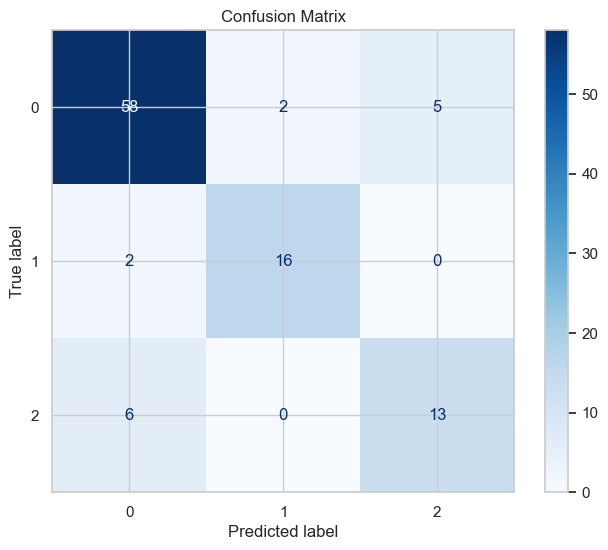

```python
params = {
        'criterion': "gini",
        'max_depth': 9,
        'n_estimators': 40,
}
randomForestClassifier = runModel(RandomForestModel, X_train, y_train, X_test, y_test, params)
```

## XGBoost

XGBoost (Extreme Gradient Boosting) is a specific implementation of gradient boosting that is designed to be efficient, scalable, and highly accurate. It uses a combination of techniques, such as parallel processing, tree pruning, and regularization, to optimize the training process and improve the performance of the model.

## Q38

### XGBoost: The Algorithm and Framework

1. **What is XGBoost?**
   - **XGBoost** (short for "extreme gradient boosting") is both an algorithm and an open-source framework.
   - It falls under the category of **gradient boosting**, a powerful ensemble learning technique.
2. **XGBoost the Algorithm:**
   - **Gradient Boosting Algorithm**:
     - Ensemble learning method that combines multiple models to make predictions.
     - Builds a sequence of initially weak models into increasingly more powerful ones.
     - Uses the gradient of a loss function to improve model performance.
   - **Decision Trees**:
     - XGBoost operates on decision trees.
     - Decision trees are graphs with "if" conditions (vertices) that lead to predictions.
     - The algorithm progressively adds more "if" conditions to build a stronger tree.
   - **Leaf-to-Branch Transformation**:
     - XGBoost considers whether turning a leaf into a new "if" statement with separate predictions would benefit the model.
     - This process enhances the tree's predictive power.
3. **XGBoost the Framework:**
   - **Implementation of XGBoost Algorithm**:
     - The **XGBoost framework** implements the XGBoost algorithm and other gradient boosting techniques.
     - Available in Python, R, Java, Ruby, Swift, Julia, C, and C++.
     - Widely used for structured/tabular data in machine learning competitions and real-world applications.
4. **Key Features**:
   - **Efficiency**: XGBoost is optimized for speed and performance.
   - **Flexibility**: Handles various data types and features effectively.
   - **Accuracy**: Solves many data science problems accurately.
   - **Parallel Tree Boosting**: Efficiently builds decision trees in parallel.

Source: Conversation with Bing, 5/16/2024 (1) XGBoost Simply Explained (With an Example in Python) - Springboard. https://www.springboard.com/blog/data-science/xgboost-explainer/. (2) XGBoost Documentation — xgboost 2.0.3 documentation. https://xgboost.readthedocs.io/. (3) What XGBoost is and how to optimize it - Towards Data Science. https://towardsdatascience.com/what-is-xgboost-and-how-to-optimize-it-d3c24e0e41b4. (4) XGBoost Documentation — xgboost 2.1.0-dev documentation - Read the Docs. https://xgboost.readthedocs.io/en/latest/index.html. (5) A Gentle Introduction to XGBoost for Applied Machine Learning. https://machinelearningmastery.com/gentle-introduction-xgboost-applied-machine-learning/. (6) en.wikipedia.org. https://en.wikipedia.org/wiki/XGBoost.

## Q39

1. **Gradient Boosting:**
   - **Definition:** Gradient Boosting is a powerful machine learning technique that combines multiple weak learners (usually decision trees) to create a strong ensemble model.
   - **Objective:** It aims to improve predictive accuracy by iteratively correcting the errors made by previous models.
   - **Process:**
     - Start with an initial model (often a simple one, like a shallow decision tree).
     - Compute the **residuals** (differences between actual and predicted values) for the training data.
     - Train a new model (usually another decision tree) to predict these residuals.
     - Combine the new model's predictions with the previous model's predictions.
     - Repeat the process, adjusting the weights of each model, until convergence.
   - **Advantages:**
     - Handles complex relationships and non-linearities.
     - Robust against overfitting.
     - Widely used in various domains.
2. **Tree Boosting vs. Decision Trees:**
   - **Decision Trees:**
     - Decision trees are simple, interpretable models that make sequential decisions based on features.
     - Each node in a decision tree represents a feature test, leading to different branches.
     - Decision trees can suffer from overfitting due to their high variance.
     - They are prone to capturing noise in the training data.
     - A single decision tree is a **weak learner**.
   - **Tree Boosting (Gradient Boosted Trees):**
     - Tree boosting combines multiple decision trees into an ensemble.
     - It starts with a weak model (often a shallow tree) and iteratively improves it.
     - Each new tree corrects the errors made by the previous ones.
     - The final prediction is a weighted combination of all trees.
     - Tree boosting reduces bias and variance, resulting in a more robust model.
     - Gradient Boosted Trees (GBTs) are a specific type of tree boosting using gradient descent.
   - **Key Differences:**
     - Decision trees stand alone, while tree boosting combines them.
     - Tree boosting focuses on minimizing errors, whereas decision trees aim to make individual predictions.
     - Tree boosting starts with a weak model and iteratively improves it, while decision trees are built independently.
     - GBTs use gradient descent to optimize the loss function, making them more powerful than standalone decision trees.

Source: Conversation with Bing, 5/16/2024 (1) Gradient boosting - Wikipedia. https://en.wikipedia.org/wiki/Gradient_boosting. (2) Gradient Boosting Definition | DeepAI. https://deepai.org/machine-learning-glossary-and-terms/gradient-boosting. (3) What is Gradient Boosting? - Gradient Boosting Explained - Displayr. https://www.displayr.com/gradient-boosting-the-coolest-kid-on-the-machine-learning-block/. (4) Gradient Boosting in ML - GeeksforGeeks. https://www.geeksforgeeks.org/ml-gradient-boosting/. (5) Gradient Boosting – A Concise Introduction from Scratch. https://www.machinelearningplus.com/machine-learning/gradient-boosting/. (6) Decision Tree vs Random Forest vs Gradient Boosting Machines: Explained .... https://www.datasciencecentral.com/decision-tree-vs-random-forest-vs-boosted-trees-explained/. (7) How are boosted decision stumps different from a decision tree?. https://datascience.stackexchange.com/questions/30233/how-are-boosted-decision-stumps-different-from-a-decision-tree. (8) Deep learning vs. Decision trees and boosting methods. https://stats.stackexchange.com/questions/12687/deep-learning-vs-decision-trees-and-boosting-methods.

```python
from xgboost import XGBClassifier

class XGBModel(ClassifierModel):
    def create_classifier(self, params):
        return XGBClassifier(gamma=1, learning_rate=params["learning_rate"], max_depth=params["max_depth"]
                             , n_estimators=params["n_estimators"])

    def set_search_params(self):
        return {
            'learning_rate': np.arange(0.1, 0.9, 0.05),
            'max_depth': range(5, 10),
            'n_estimators': range(1, 120, 20)
        }
```

```
model's train accuracy:  0.968
model's test accuracy:  0.873
Best hyperparameters: {'learning_rate': 0.6000000000000002, 'max_depth': 5, 'n_estimators': 21}
Best model's train accuracy score: 0.861
Best model's test score: 0.902
Classification report :
              precision    recall  f1-score   support

           0       0.88      0.92      0.90        65
           1       1.00      0.89      0.94        18
           2       0.72      0.68      0.70        19

    accuracy                           0.87       102
   macro avg       0.87      0.83      0.85       102
weighted avg       0.87      0.87      0.87       102
```

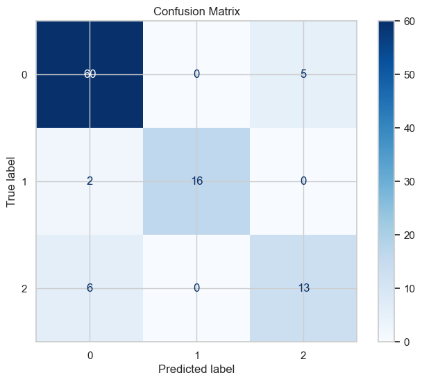

```python
params = {
    "learning_rate" : 0.1,
    "max_depth" : 8,
    "n_estimators": 50
}
xgbClassifier = runModel(XGBModel, X_train, y_train, X_test, y_test, params)
```